# FISH ABUNDANCE AND RICHNESS MODELS

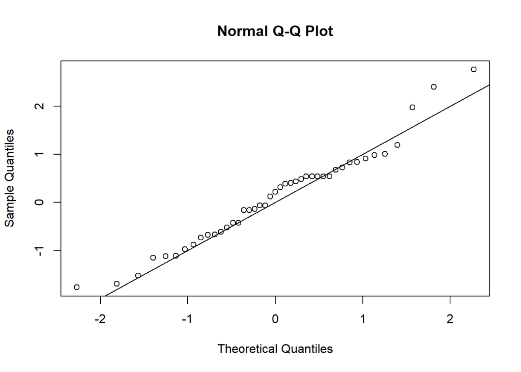

```r
qqnorm(residuals(m16)) # qqnorm plot
abline(a = 0, b = 1) # add 1:1 line
```

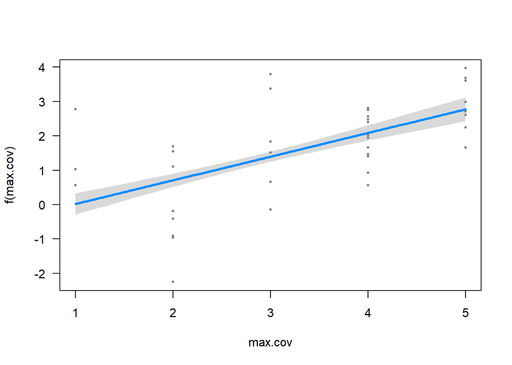

```r
visreg::visreg(m16, "max.cov")
```

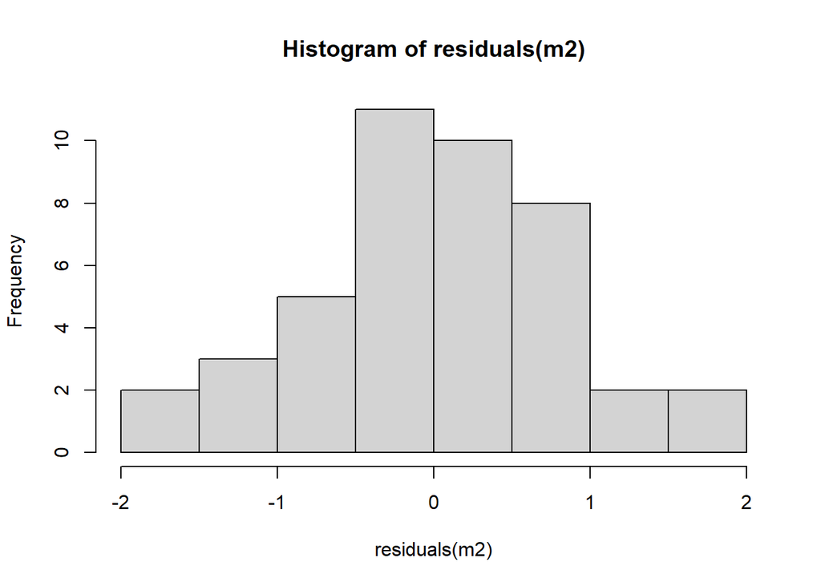

```r
hist(residuals(m2)) # look  at residuals
```

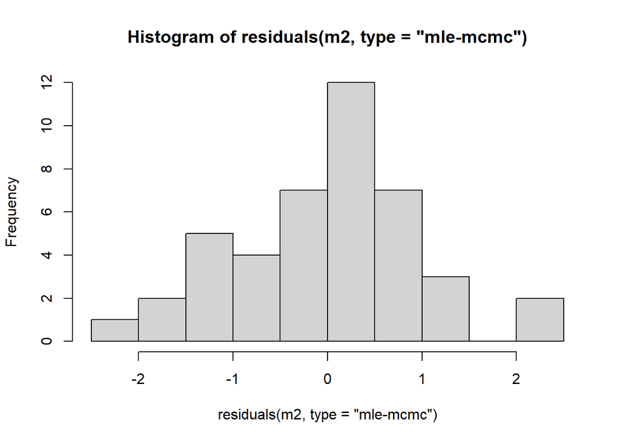

```r
hist(residuals(m2, type = "mle-mcmc")) # another way to calculate them using mcmc, got from Philina's mesh building vignette
```

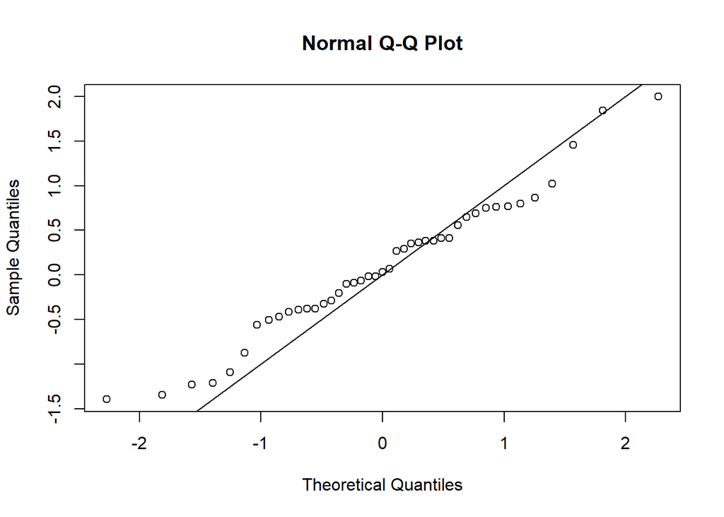

```r
qqnorm(residuals(m2)) # qqnorm plot
abline(a = 0, b = 1) # add 1:1 line
```

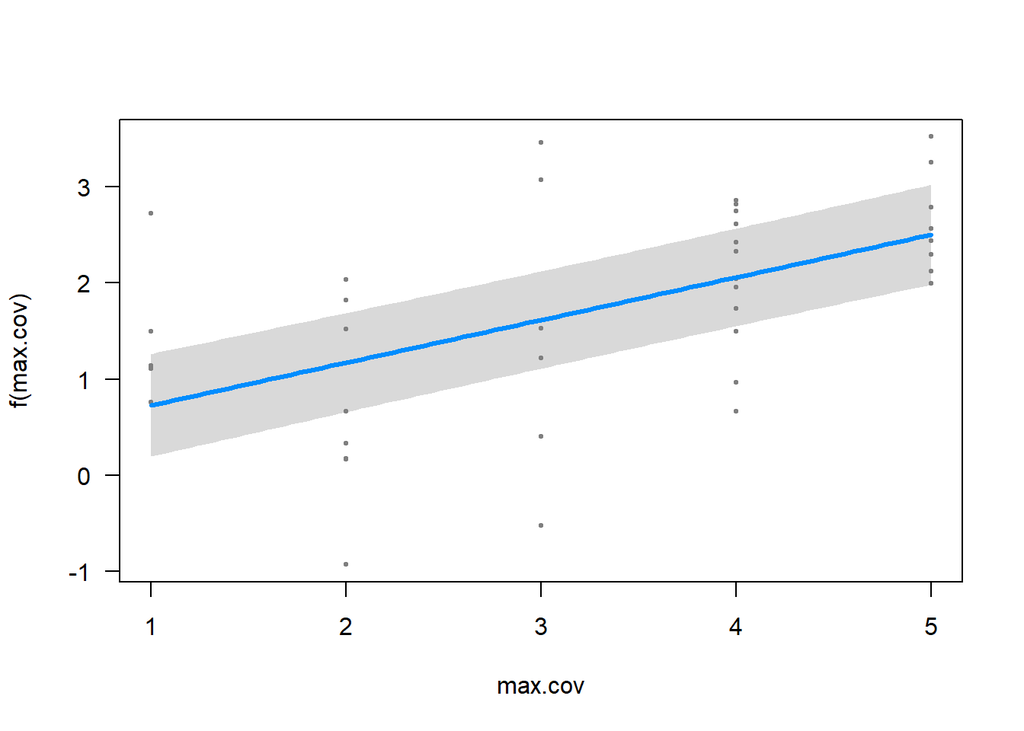

```r
visreg::visreg(m2, "max.cov")
```

### okay I vote we scrap complexity and go back to the original model set becuase then we have more data to use because we can include larsen bay see below dataset as test

# Rockfish richness

## Non-schooling rockfish models (no yellowtail)

### Question 1. Does rockfish richness differ between rocky reefs, sponge gardens and sponge reefs?

(*Do we have enough data on sponge reefs? Should we add them to bioherms? rocky reefs? Hmmm question for discussion). Fitting a negbinom2 because count data and zeros but it is not currently converging….

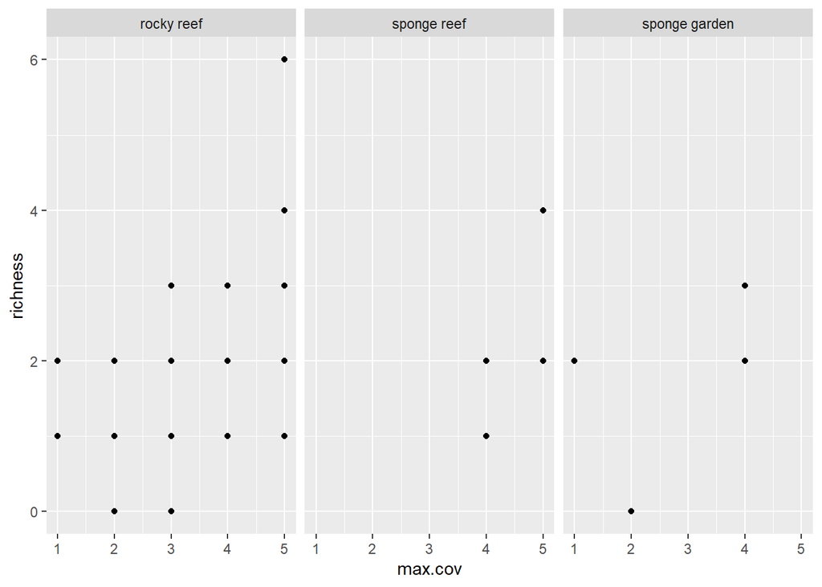

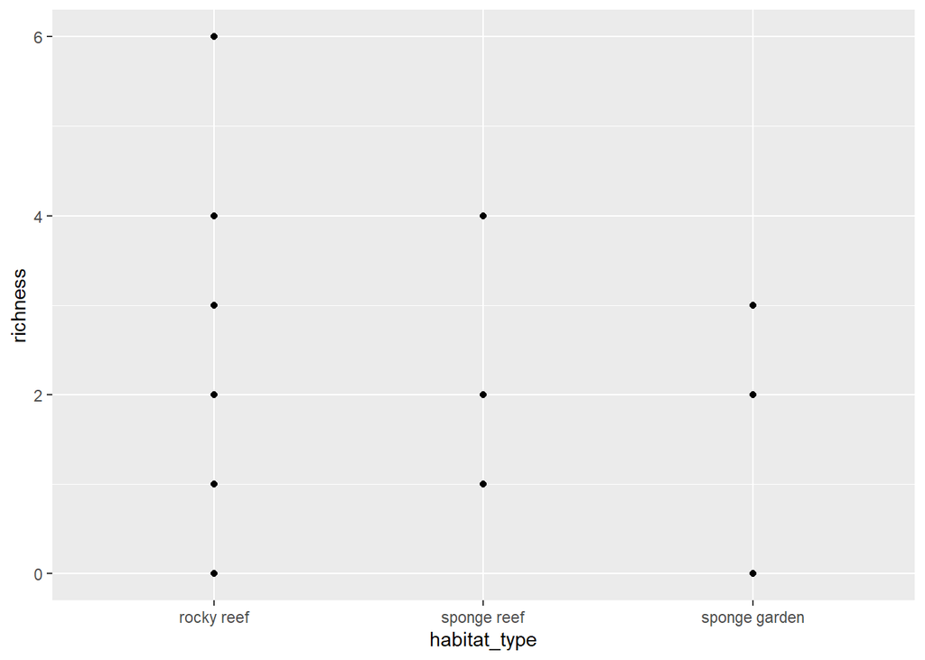

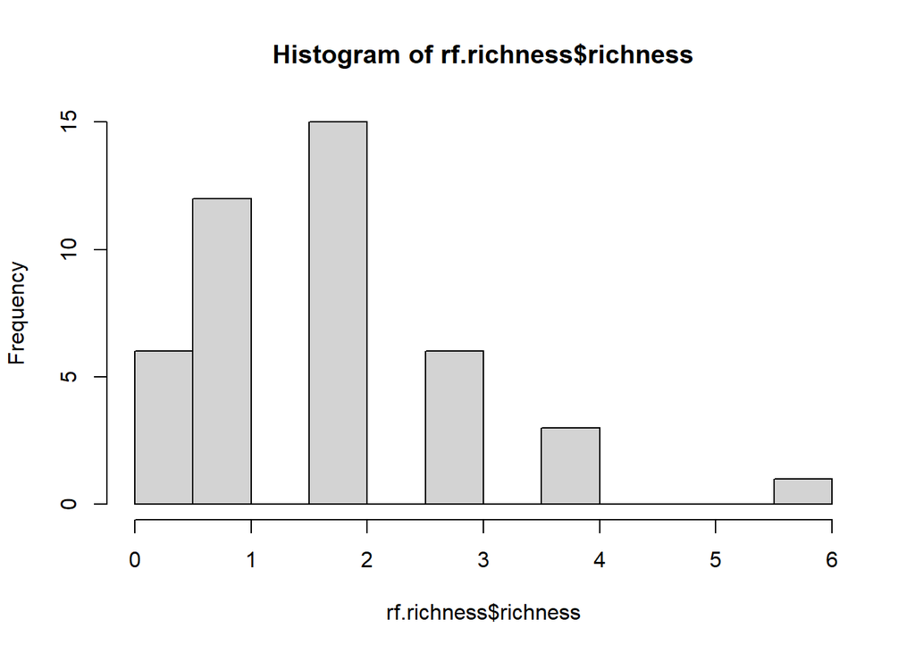

Not working….

```r
# Simple comparison between a NULL model and one with habitat type

null.rich <- sdmTMB(formula = richness ~ 0 + (1|site), mesh = mesh, spatial = "off", family = nbinom2(link = "log"),
            data = rf.richness, control = sdmTMBcontrol(newton_loops = 3))

rich1 <- sdmTMB(formula = richness ~ 0 + habitat_type + (1|site), mesh = mesh, spatial = "off", family = nbinom2(link = "log"),
                data = rf.richness, control = sdmTMBcontrol(newton_loops = 3))
AICtab(null.rich, rich1)
```

```
##           dAIC df
## rich1     0.0  5
## null.rich 4.3  2
```

```r
sanity(rich1)
```

```
## ✖ Non-linear minimizer did not converge: do not trust this model!
```

```
## ℹ Try simplifying the model, adjusting the mesh, or adding priors
```

```
## ✖ Non-positive-definite Hessian matrix: model may not have converged
## ℹ Try simplifying the model, adjusting the mesh, or adding priors
```

```
## ✔ No extreme or very small eigenvalues detected
```

```
## ✔ No gradients with respect to fixed effects are >= 0.001
```

```
## ✖ `ln_phi` standard error is NA
```

```
## ℹ Try simplifying the model, adjusting the mesh, or adding priors
```

```
## ✖ `phi` standard error is NA
## ℹ Try simplifying the model, adjusting the mesh, or adding priors
```

```
## ✔ No standard errors look unreasonably large
```

[output not shown]

```
## ✔ No sigma parameters are < 0.01
```

```
## ✔ No sigma parameters are > 100
```

```r
summary(rich1)
```

```
## Model fit by ML ['sdmTMB']
## Formula: richness ~ 0 + habitat_type + (1 | site)
## Mesh: mesh
## Data: rf.richness
## Family: nbinom2(link = 'log')
```

[output not shown]

[output cut: 16 more lines]

[output not shown]

```
##
##                           coef.est coef.se
## habitat_typerocky reef        0.61    0.16
## habitat_typesponge reef       0.62    0.30
## habitat_typesponge garden     0.10    0.44
##
## Random intercepts:
##      Std. Dev.
## site      0.29
##
## Dispersion parameter: 10463761.22
## ML criterion at convergence: 67.603
##
## See ?tidy.sdmTMB to extract these values as a data frame.
```

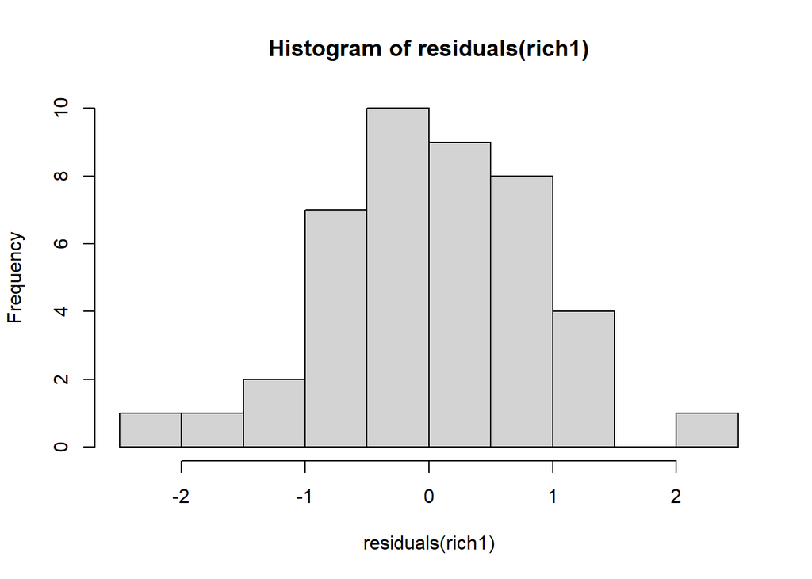

```r
hist(residuals(rich1))
```

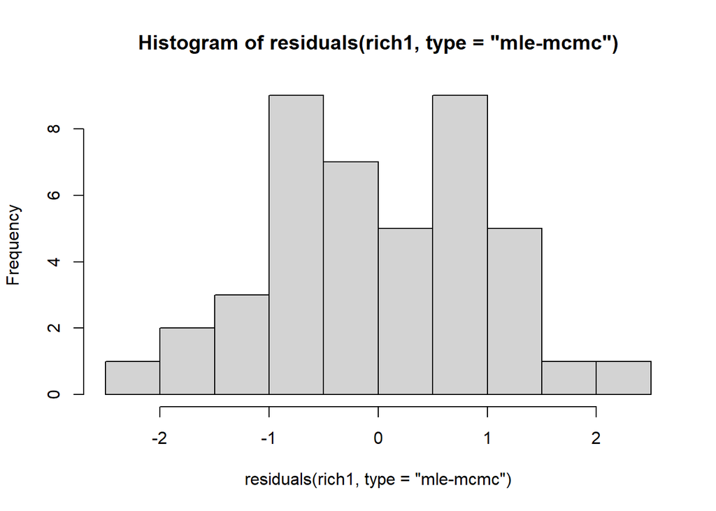

```r
hist(residuals(rich1, type = "mle-mcmc")) # another way to calculate them using mcmc, got from Philina's mesh building vignette
```

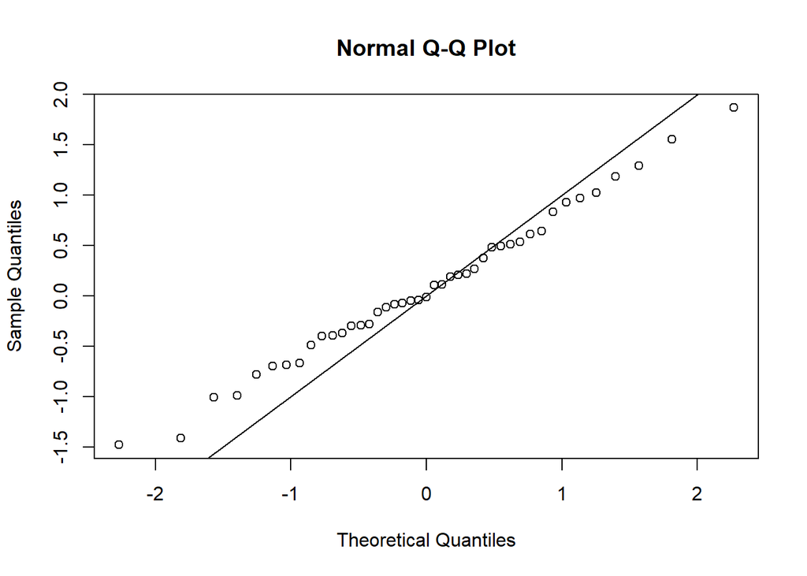

```r
qqnorm(residuals(rich1)) # qqnorm plot
abline(a = 0, b = 1) # add 1:1 line
```

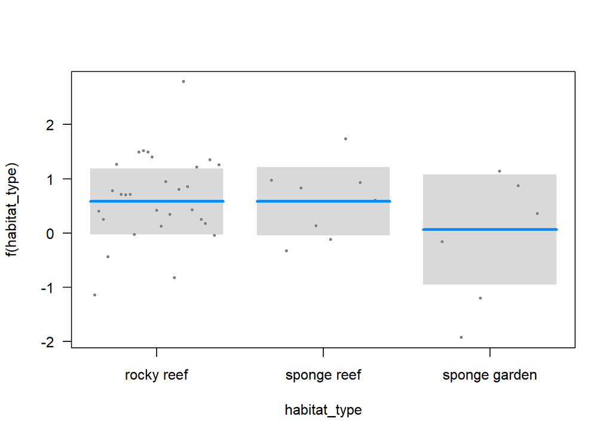

```r
visreg::visreg(rich1, "habitat_type")
```

# Lengths

```
## # A tibble: 1,754 × 35
##    Filename Frame Time …¹ Period Perio…² lengt…³ Preci…⁴ RMS (…⁵ Range…⁶ Direc…⁷
##    <chr>    <dbl>   <dbl> <chr>    <dbl>   <dbl>   <dbl>   <dbl>   <dbl>   <dbl>
##  1 Left (2… 20248    28.9 <NA>    NA         NA     1.34   0.472   1022.    4.95
##  2 Left (2… 20338    28.9 <NA>    NA         NA     1.19   0.252    951.    2.62
##  3 Left (2… 20580    29.1 <NA>    NA         NA     1.34   0.151   1018.    5.45
##  4 Left (2… 20670    29.1 <NA>    NA         NA     1.20   0.14     944.   10.9
##  5 Left (2… 20873    29.2 <NA>    NA         NA     1.35   0.341   1024.    5.61
##  6 Left (2… 20963    29.3 <NA>    NA         NA     1.22   0.32     961.    5.67
##  7 Left (2… 26544    32.4 <NA>    NA        258.    0.92   1.10     816.   13.5
##  8 Left (2… 26574    32.4 <NA>    NA        219.    1.03   0.249    783.   25.0
##  9 Left (2… 27623    33.0 60min…   0.495    257.    3.28   0.375   1536.   26.6
## 10 Left (2… 27738    33.1 60min…   0.559    225.    2.73   0.414   1427.    6.89
## # … with 1,744 more rows, 25 more variables: `Horz. Dir. (deg)` <dbl>,
## #   `Vert. Dir. (deg)` <dbl>, `Mid X (mm)` <dbl>, `Mid Y (mm)` <dbl>,
## #   `Mid Z (mm)` <dbl>, OpCode <chr>, TapeReader <chr>, Depth <dbl>,
## #   Comment...19 <lgl>, Date <chr>, Time <time>, habitat_type <chr>,
## #   complexity <lgl>, current_speed <lgl>, temperature <lgl>,
## #   left_camera <dbl>, right_camera <dbl>, Family <chr>, Genus <chr>,
## #   Species <chr>, Code <dbl>, Number <dbl>, Stage <chr>, Activity <chr>, …
```

```
## # A tibble: 22 × 1
##    site
##    <chr>
##  1 birdislet
##  2 christiebuoy
##  3 cliffcove
##  4 defenceinshorebioherm
##  5 defenceoffshorebioherm
##  6 defencesouthside
##  7 halkettbayeast
##  8 halkettbioherm
##  9 halkettsign
## 10 helipad
## 11 huttcloudpair
## 12 larsenbay
## 13 NEbowyer
## 14 Nechristie
## 15 northpamrocks
## 16 Nwpassage
## 17 passagebioherm
## 18 porteaurockpile
## 19 porteauslide
## 20 southpassage
## 21 tennisboatramp
## 22 tenniscourts
```

```
## # A tibble: 25 × 1
##    site
##    <chr>
##  1 ansellpoint
##  2 birdislet
##  3 bootspongewall
##  4 christiebuoy
##  5 cliffcove
##  6 defenceinshorebioherm
##  7 defenceoffshorebioherm
##  8 defencesouthside
##  9 fieldof1000
## 10 halkettbayeast
## 11 halkettbioherm
## 12 halkettsign
## 13 helipad
## 14 huttcloudpair
## 15 larsenbay
## 16 NEbowyer
## 17 Nechristie
## 18 northpamrocks
## 19 Nwpassage
## 20 passagebioherm
## 21 porteaurockpile
## 22 porteauslide
## 23 southpassage
## 24 tennisboatramp
## 25 tenniscourts
```

```
## # A tibble: 210 × 45
##    Filename Frame Time …¹ Period Perio…² lengt…³ Preci…⁴ RMS (…⁵ Range…⁶ Direc…⁷
##    <chr>    <dbl>   <dbl> <chr>    <dbl>   <dbl>   <dbl>   <dbl>   <dbl>   <dbl>
##  1 Left_00…   887    35.9 30min…  12.0      292.   11.4    1.20    2698.    38.3
##  2 Left_00…  1883    36.4 30min…  12.6      367.    4.00   0.485   1747.    34.5
##  3 Left (2… 13128    24.9 60min   10.4      204.    3.05   1.29    1153.    31.3
##  4 Left (2… 18891    28.1 60min   13.6      312.    4.13   1.12    1170.    26.1
##  5 Left (2… 29861    34.2 60min    1.38     288.    2.40   0.148   1156.    12.6
##  6 Left (3…  2111    36.4 60min    3.59     137.    1.48   0.471    970.    11.7
##  7 Left (6…  8798    93.1 <NA>    NA        305.    1.09   0.845    926.    14.1
##  8 Left (2… 16792    27.0 60min    0.866    300.    9.45   3.81    1898.    34.6
##  9 Left (3…   409    35.5 60min    9.39     275.    5.19   1.01    1876.    17.0
## 10 Left (3…  4232    37.6 60min   11.5      339.    3.96   0.639   1202.    21.4
## # … with 200 more rows, 35 more variables: `Horz. Dir. (deg)` <dbl>,
## #   `Vert. Dir. (deg)` <dbl>, `Mid X (mm)` <dbl>, `Mid Y (mm)` <dbl>,
## #   `Mid Z (mm)` <dbl>, OpCode <chr>, TapeReader <chr>, Depth <dbl>,
## #   Comment...19 <lgl>, Date <chr>, Time <time>, habitat_type <chr>,
## #   complexity <lgl>, current_speed <lgl>, temperature <lgl>,
## #   left_camera <dbl>, right_camera <dbl>, Family <chr>, Genus <chr>,
## #   Species <chr>, Code <dbl>, Number <dbl>, Stage <chr>, Activity <chr>, …
```

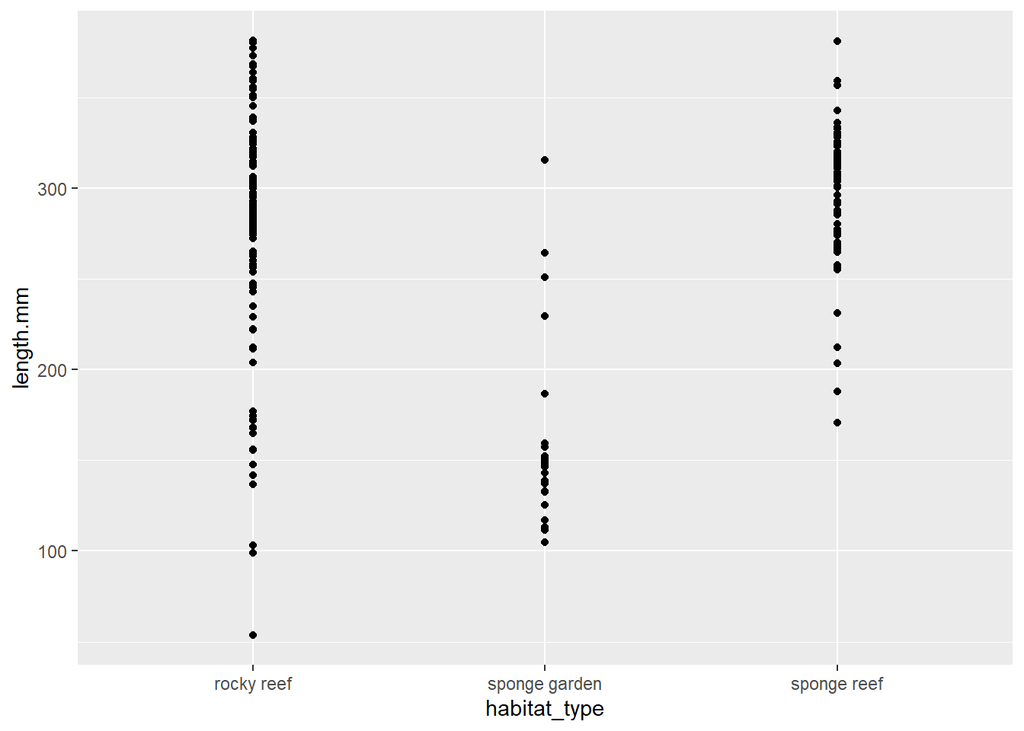

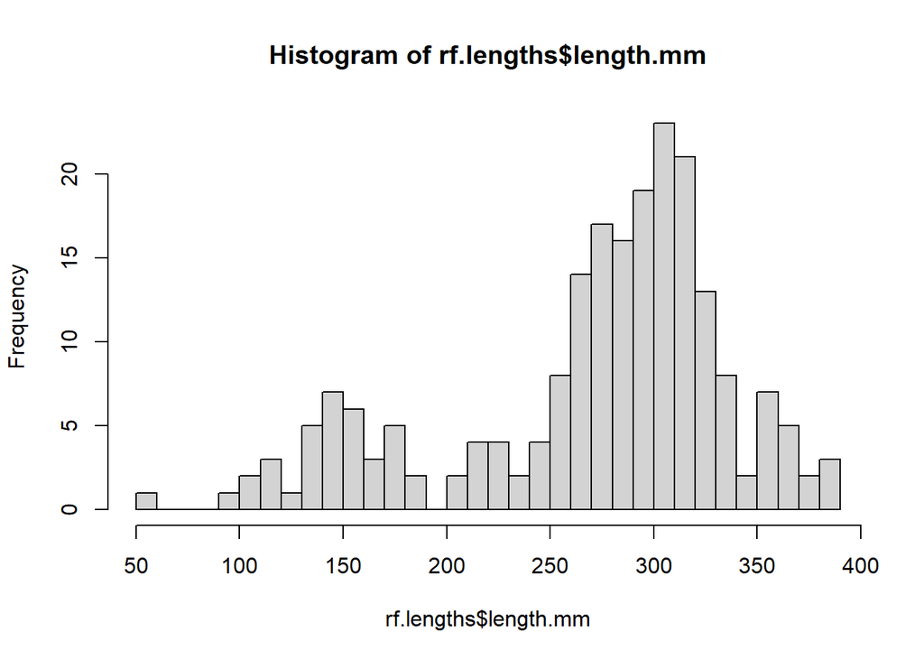

```r
null.length <- sdmTMB(formula = length.mm ~ 0 + (1|site), mesh = mesh, spatial = "off", family = gaussian(link = "identity"),
            data = rf.lengths, control = sdmTMBcontrol(newton_loops = 3))

length.hab <- sdmTMB(formula = length.mm ~ 0 + habitat_type + (1|site), mesh = mesh, spatial = "off", family = gaussian(link = "identity"),
            data = rf.lengths, control = sdmTMBcontrol(newton_loops = 3))


AICtab(null.length, length.hab)
```

```
##             dAIC df
## length.hab   0   5
## null.length 68   2
```

```r
sanity(length.hab)
```

```
## ✔ Non-linear minimizer suggests successful convergence
```

```
## ✔ Hessian matrix is positive definite
```

```
## ✔ No extreme or very small eigenvalues detected
```

```
## ✔ No gradients with respect to fixed effects are >= 0.001
```

```
## ✔ No fixed-effect standard errors are NA
```

```
## ✔ No standard errors look unreasonably large
```

```
## ✔ No sigma parameters are < 0.01
```

```
## ✔ No sigma parameters are > 100
```

```r
summary(length.hab)
```

```
## Model fit by ML ['sdmTMB']
## Formula: length.mm ~ 0 + habitat_type + (1 | site)
## Mesh: mesh
## Data: rf.lengths
## Family: gaussian(link = 'identity')
##
##                           coef.est coef.se
## habitat_typerocky reef      266.94   11.68
## habitat_typesponge garden   161.27   44.04
## habitat_typesponge reef     284.37   22.66
##
## Random intercepts:
##      Std. Dev.
## site     43.06
##
## Dispersion parameter: 44.39
## ML criterion at convergence: 1116.518
##
## See ?tidy.sdmTMB to extract these values as a data frame.
```

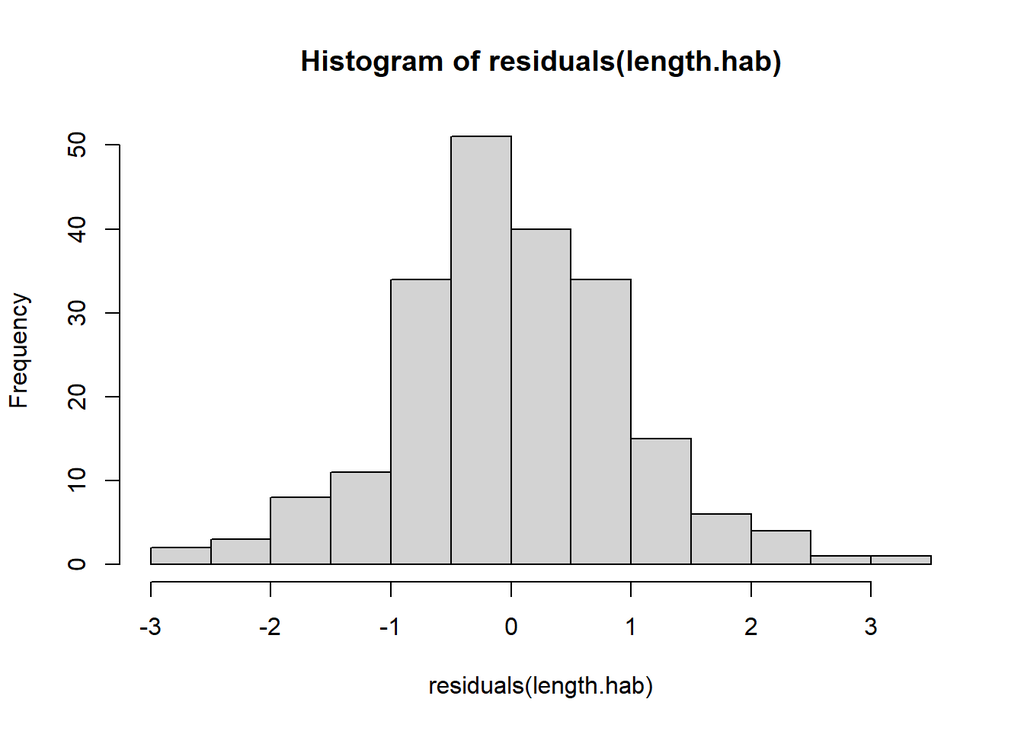

```r
hist(residuals(length.hab))
```

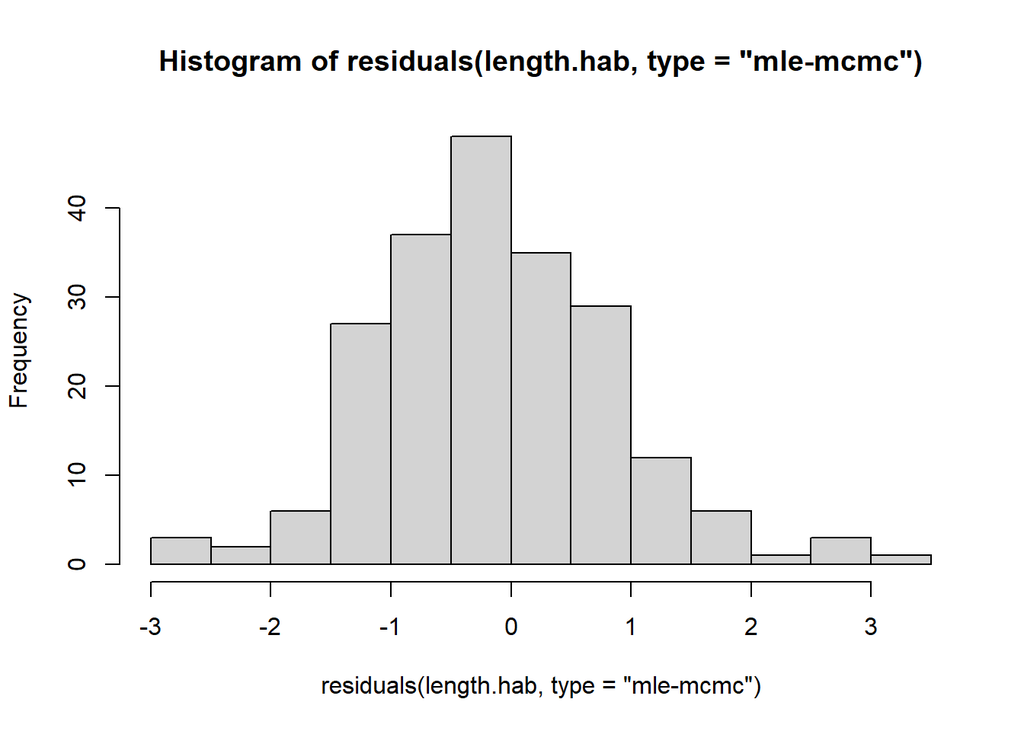

```r
hist(residuals(length.hab, type = "mle-mcmc")) # another way to calculate them using mcmc, got from Philina's mesh building vignette
```

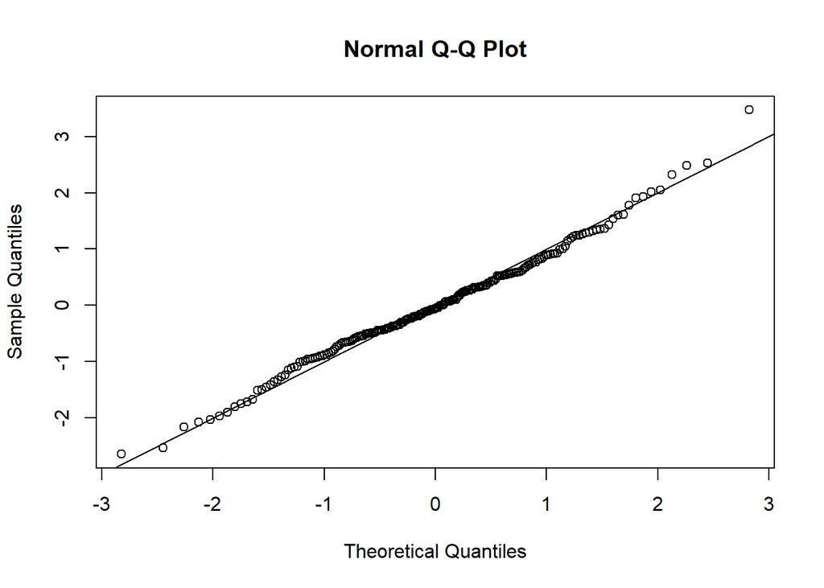

```r
qqnorm(residuals(length.hab)) # qqnorm plot
abline(a = 0, b = 1) # add 1:1 line
```

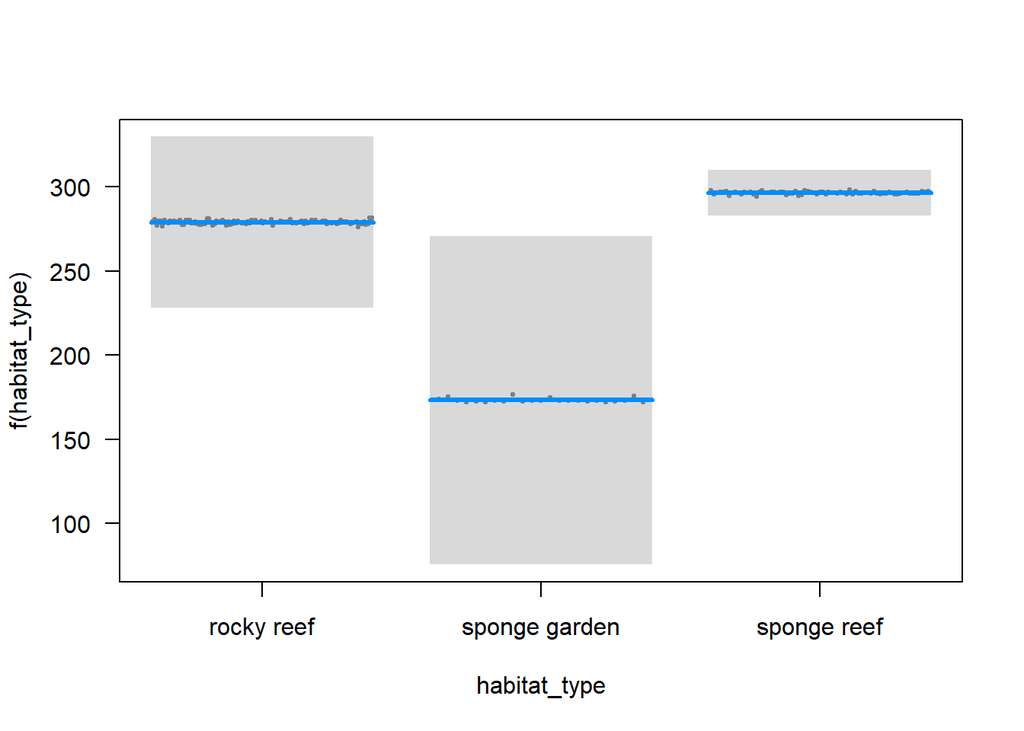

```r
visreg::visreg(length.hab, "habitat_type")
```